# hw9

Austin Melendez

2025-11-21

```r
library(car)
library(ISLR2)
```

## 1

Using the `Weekly` data produce some numerical and graphical summaries. Do there appear to be any patterns?

```r
data(Weekly)

summary(Weekly)
```

```
##       Year           Lag1               Lag2               Lag3
##  Min.   :1990   Min.   :-18.1950   Min.   :-18.1950   Min.   :-18.1950
##  1st Qu.:1995   1st Qu.: -1.1540   1st Qu.: -1.1540   1st Qu.: -1.1580
##  Median :2000   Median :  0.2410   Median :  0.2410   Median :  0.2410
##  Mean   :2000   Mean   :  0.1506   Mean   :  0.1511   Mean   :  0.1472
##  3rd Qu.:2005   3rd Qu.:  1.4050   3rd Qu.:  1.4090   3rd Qu.:  1.4090
##  Max.   :2010   Max.   : 12.0260   Max.   : 12.0260   Max.   : 12.0260
##       Lag4               Lag5              Volume            Today
##  Min.   :-18.1950   Min.   :-18.1950   Min.   :0.08747   Min.   :-18.1950
##  1st Qu.: -1.1580   1st Qu.: -1.1660   1st Qu.:0.33202   1st Qu.: -1.1540
##  Median :  0.2380   Median :  0.2340   Median :1.00268   Median :  0.2410
##  Mean   :  0.1458   Mean   :  0.1399   Mean   :1.57462   Mean   :  0.1499
##  3rd Qu.:  1.4090   3rd Qu.:  1.4050   3rd Qu.:2.05373   3rd Qu.:  1.4050
##  Max.   : 12.0260   Max.   : 12.0260   Max.   :9.32821   Max.   : 12.0260
##  Direction
##  Down:484
##  Up  :605
##
##
##
##
```

Looking at the data summary, our data is spread out between 1990 and 2010. Each `Lag#` variable has a spread of data, no variable looks to have a worrisome range. Additionally, the `Direction` variable has a good mix of both up and down and does not have an overwhelming skew.

```r
cor(Weekly[, c("Lag1","Lag2","Lag3","Lag4","Lag5","Volume","Today")])
```

```
##                Lag1        Lag2        Lag3         Lag4         Lag5
## Lag1    1.000000000 -0.07485305  0.05863568 -0.071273876 -0.008183096
## Lag2   -0.074853051  1.00000000 -0.07572091  0.058381535 -0.072499482
## Lag3    0.058635682 -0.07572091  1.00000000 -0.075395865  0.060657175
## Lag4   -0.071273876  0.05838153 -0.07539587  1.000000000 -0.075675027
## Lag5   -0.008183096 -0.07249948  0.06065717 -0.075675027  1.000000000
## Volume -0.064951313 -0.08551314 -0.06928771 -0.061074617 -0.058517414
## Today  -0.075031842  0.05916672 -0.07124364 -0.007825873  0.011012698
##             Volume        Today
## Lag1   -0.06495131 -0.075031842
## Lag2   -0.08551314  0.059166717
## Lag3   -0.06928771 -0.071243639
## Lag4   -0.06107462 -0.007825873
## Lag5   -0.05851741  0.011012698
## Volume  1.00000000 -0.033077783
## Today  -0.03307778  1.000000000
```

There aren’t any super strongly correlated variables in the dataset, infact most of the variables are ever so slightly negatively correlated with eachother.

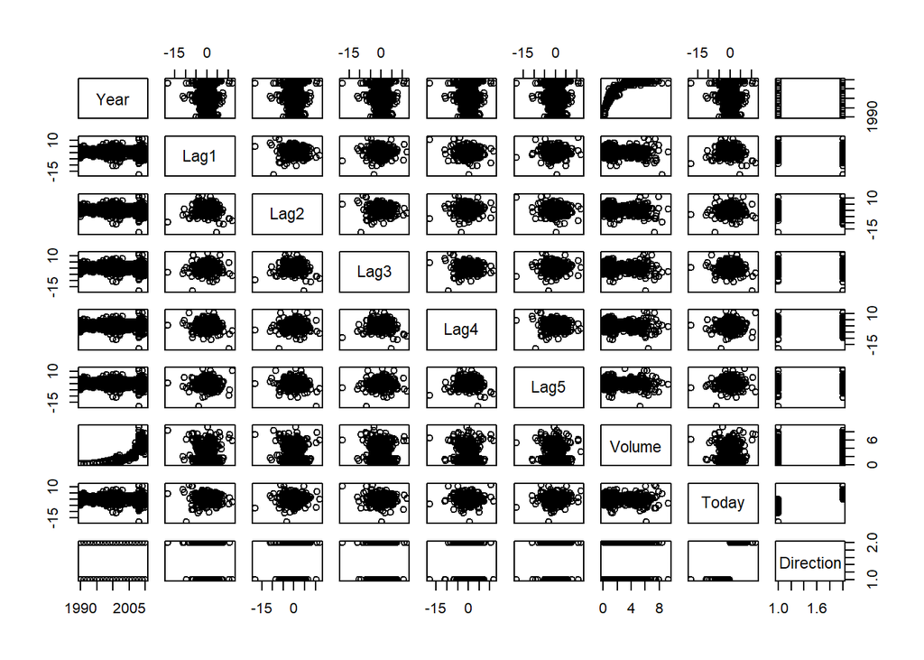

```r
plot(Weekly)
```

## 2

Perform a logistic regression using `Direction` as the response and theg five `lag` variables plus `volume` as predictors. Do any of the predictors appear to be statistically significant?

```r
mod <- glm(Direction ~ Lag1 + Lag2 + Lag3 + Lag4 + Lag5 + Volume, data = Weekly, family = binomial)

summary(mod)
```

```
##
## Call:
## glm(formula = Direction ~ Lag1 + Lag2 + Lag3 + Lag4 + Lag5 +
##     Volume, family = binomial, data = Weekly)
##
## Coefficients:
##             Estimate Std. Error z value Pr(>|z|)
## (Intercept)  0.26686    0.08593   3.106   0.0019 **
## Lag1        -0.04127    0.02641  -1.563   0.1181
## Lag2         0.05844    0.02686   2.175   0.0296 *
## Lag3        -0.01606    0.02666  -0.602   0.5469
## Lag4        -0.02779    0.02646  -1.050   0.2937
## Lag5        -0.01447    0.02638  -0.549   0.5833
## Volume      -0.02274    0.03690  -0.616   0.5377
## ---
## Signif. codes:  0 '***' 0.001 '**' 0.01 '*' 0.05 '.' 0.1 ' ' 1
##
## (Dispersion parameter for binomial family taken to be 1)
##
##     Null deviance: 1496.2  on 1088  degrees of freedom
## Residual deviance: 1486.4  on 1082  degrees of freedom
## AIC: 1500.4
##
## Number of Fisher Scoring iterations: 4
```

According to our logistic regression model using those predictors, the `Lag2` variable is statistically signigicant at the 0.05 level.

## 3

Examine the model diagnostics for your logistic regression model.

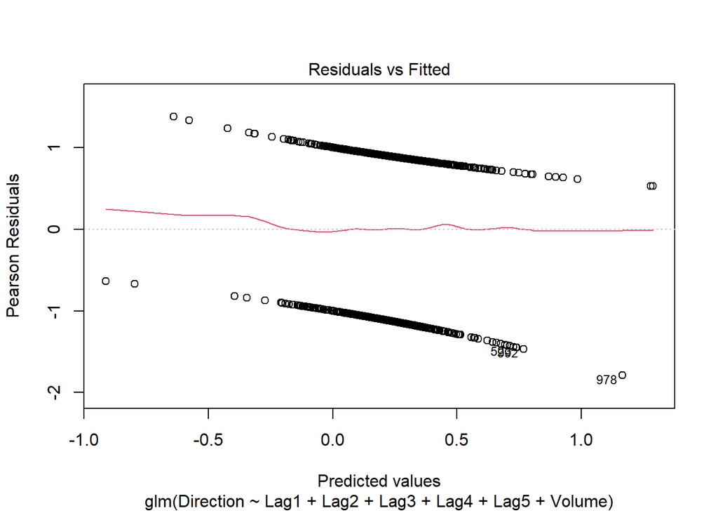

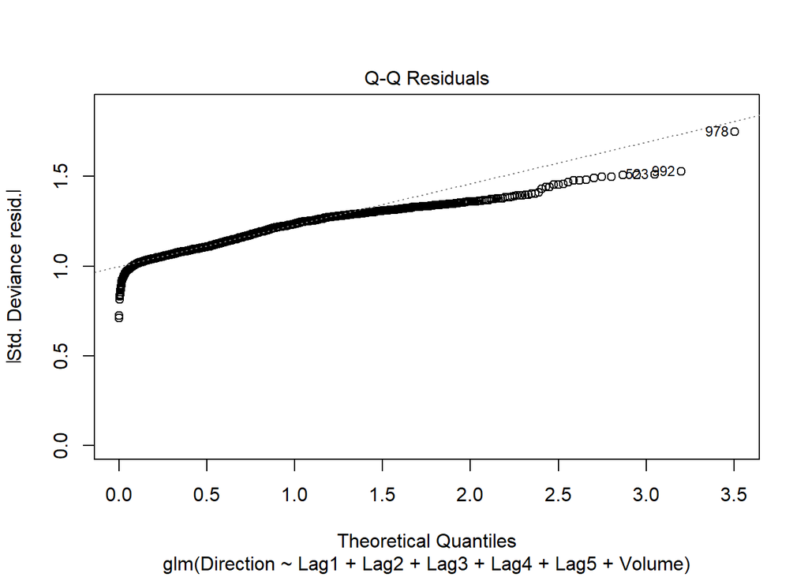

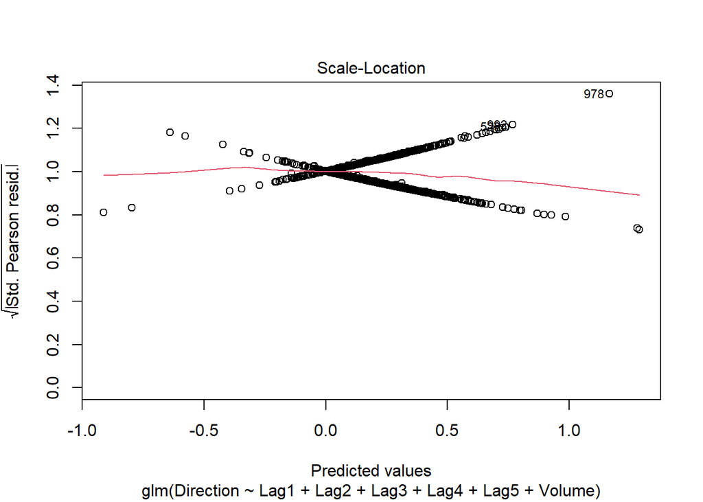

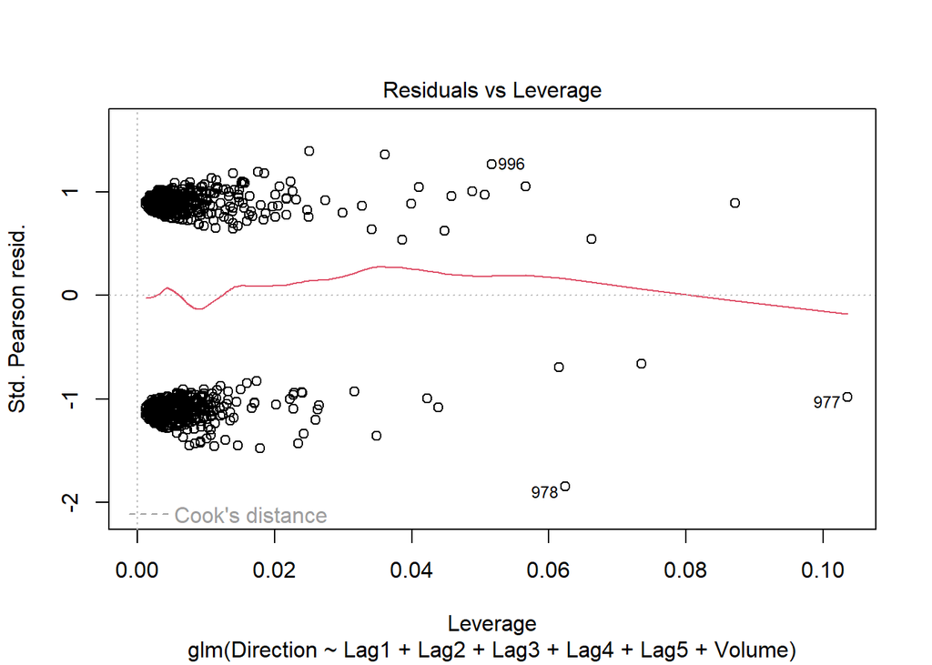

```r
plot(mod)
```

## 4

Compute the confusion matrix and overall fraction of correct predictions

```r
prob_full <- predict(mod, type = "response")
pred_full <- ifelse(prob_full > 0.5, "Up", "Down")

tab_full <- table(Predicted = pred_full, Actual = Weekly$Direction)

print(tab_full)
```

```
##          Actual
## Predicted Down  Up
##      Down   54  48
##      Up    430 557
```

As you can see, we are incorrectly classifying a lot of `Down` cases as `Up` instead. But we are pretty accurate when it comes to accurately classifying `Up` as `Up`.

```r
TP <- tab_full["Up","Up"]
FP <- tab_full["Up","Down"]
TN <- tab_full["Down","Down"]
FN <- tab_full["Down","Up"]
cat("TP:",TP," FP:",FP," TN:",TN," FN:",FN,"\n")
```

```
## TP: 557  FP: 430  TN: 54  FN: 48
```

Our model classified 557 `Up` labels correctly (true positive), it classified 430 `Down` labels incorrectly as `Up` (false positive), it classified 54 `Down` labels correctly (true negative), and classified 48 `Up` labels incorrectly as `Down`.

```r
acc <- sum(diag(tab_full)) / sum(tab_full)
round(acc, 4)
```

```
## [1] 0.5611
```

Due to our high false positive, we are only correctly classifying 56% of our data correctly.

## 5

Fit the logistic regression model with Lag2 as the only predictor. Compute teh confusion matrix and overall fraction of correct predictions. How does this model compare?

```r
lag2_mod <- glm(Direction ~ Lag2, data = Weekly, family = binomial)
summary(lag2_mod)
```

```
##
## Call:
## glm(formula = Direction ~ Lag2, family = binomial, data = Weekly)
##
## Coefficients:
##             Estimate Std. Error z value Pr(>|z|)
## (Intercept)  0.21473    0.06123   3.507 0.000453 ***
## Lag2         0.06279    0.02636   2.382 0.017230 *
## ---
## Signif. codes:  0 '***' 0.001 '**' 0.01 '*' 0.05 '.' 0.1 ' ' 1
##
## (Dispersion parameter for binomial family taken to be 1)
##
##     Null deviance: 1496.2  on 1088  degrees of freedom
## Residual deviance: 1490.4  on 1087  degrees of freedom
## AIC: 1494.4
##
## Number of Fisher Scoring iterations: 4
```

```r
prob_lag2 <- predict(lag2_mod, type = "response")
pred_lag2 <- ifelse(prob_lag2 > 0.5, "Up", "Down")

tab_lag2 <- table(Predicted = pred_lag2, Actual = Weekly$Direction)

print(tab_lag2)
```

```
##          Actual
## Predicted Down  Up
##      Down   33  26
##      Up    451 579
```

Our confusion matrix looks about the same! We’ve actually increased our false positive rate by nearly 20 observations.

```r
TP <- tab_lag2["Up","Up"]
FP <- tab_lag2["Up","Down"]
TN <- tab_lag2["Down","Down"]
FN <- tab_lag2["Down","Up"]
cat("TP:",TP," FP:",FP," TN:",TN," FN:",FN,"\n")
```

```
## TP: 579  FP: 451  TN: 33  FN: 26
```

```r
acc2 <- sum(diag(tab_lag2)) / sum(tab_lag2)
round(acc2, 4)
```

```
## [1] 0.562
```

Like our original model, we are only correctly classifying 56% of our data correctly.

## 6

Provide at least one way to interpret the coefficient associated with Lag2 in your model.

```r
coef_lag2 <- coef(lag2_mod)["Lag2"]
odds_ratio_lag2 <- exp(coef_lag2)
round(coef_lag2,4)
```

```
##   Lag2
## 0.0628
```

$0.0628$ is the Lag2 coefficiant (log-odds).

```r
round(odds_ratio_lag2,4)
```

```
##   Lag2
## 1.0648
```

Therefore, the calcualted odds ratio for a 1-unit increase in Lag2 is $1.0648$

```r
se <- sqrt(vcov(lag2_mod)["Lag2","Lag2"])
ci_low <- exp(coef_lag2 - 1.96*se)
ci_high <- exp(coef_lag2 + 1.96*se)

round(ci_low,4)
```

```
##   Lag2
## 1.0112
```

```r
round(ci_high,4)
```

```
##   Lag2
## 1.1213
```

Our 95% CI for odds ratio of `Lag2` is [1.0112, 1.1213]

Holding other variables constant, a one-point higher `Lag2` is associated with 6.48% increase in the odds of an `Up` week.